# Estudio seguridad red de Oficinas BBVA

Head of Data - Seguridad

# Home

### ABSTRACT

Se plantea la necesidad de realizar un estudio estadístico que permita determinar las necesidades de seguridad a atender para cada una de las sucursales del BBVA en Colombia. En este sentido, el objetivo es cuantificar el riesgo de hurto para cada sucursal, dependiendo de su ubicación geográfica.

### ORIGEN DE LA INFORMACIÓN

Como punto de partida, el presente estudio determinó como fuente de información las [Estadísticas delictivas de la Policía Nacional](https://www.policia.gov.co/grupo-informaci%C3%B3n-criminalidad/estadistica-delictiva).

### VANDALISMOS

[interactive chart not shown]

# Mapas

### LOCALIZACIÓN DE VANDALISMO Y HURTOS

[interactive chart not shown]

# Comparación con otra entidad financiera

**COMPARACIÓN CON OTRA ENTIDAD FINANCIERA**

Para determinar si la vandalización de cajeros de BBVA se comporta de manera similar a la presentada por otras entidades del sector, se compararon los datos generales con los de otra Entidad del sector.

Los valores presentados corresponden al promedio de las medidas mensuales de Enero a Julio de 2019 para BBVA y la Entidad X.

### CAJEROS VANDALIZADOS BBVA

```r
gauge(20, min = 0, max = 100, symbol = '%')
```

[interactive chart not shown]

### CAJEROS VANDALIZADOS ENTIDAD X

```r
gauge(33.45, min = 0, max = 100, symbol = '%')
```

[interactive chart not shown]

### **BBVA** - 11.23% de los cajeros vandalizados fueron atacados en este mes

```r
valueBox('Mayo')
```

Mayo

### **Entidad X** - 15.11% de los cajeros vandalizados fueron atacados en este mes

```r
valueBox('Marzo', color="grey")
```

Marzo

### PARTES VANDALIZADAS

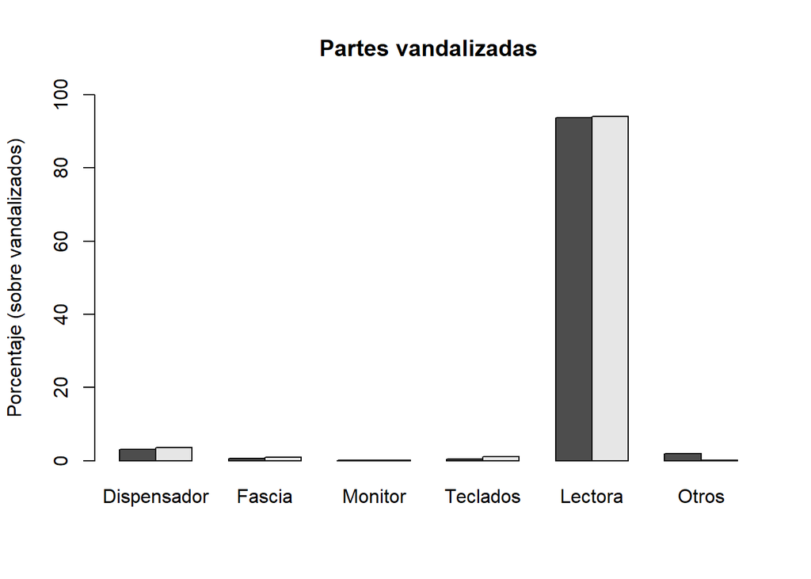

```r
table1 <- matrix(c(3.10, 0.68, 0.05, 0.52, 93.78, 1.88, 3.52, 0.95, 0.19, 1.03, 94.12, 0.18),ncol=6,byrow=TRUE)
colnames(table1) <- c("Dispensador","Fascia", "Monitor", "Teclados", "Lectora", "Otros")
rownames(table1) <- c("BBVA", "Entidad X")

barplot(table1, main = "Partes vandalizadas", ylab = "Porcentaje (sobre vandalizados)", beside = TRUE, ylim = c(0,100))
```

# Análisis estadístico

**ANÁLISIS ESTADÍSTICO**

A continuación se presentan estadísticas obtenidas de la exploración inicial de los datos.

### De los cajeros vandalizados tienen **nivel 7 de aprovisionamiento**

```r
valueBox("94.58 %", icon="ion-card", color = "green")
```

94.58 %

### De los cajeros vandalizados tienen **nivel 4 de aprovisionamiento**

```r
valueBox("5.42 %", icon="ion-card", color = "orange")
```

5.42 %

### DISTRIBUCIÓN EVENTOS DE VANDALISMO

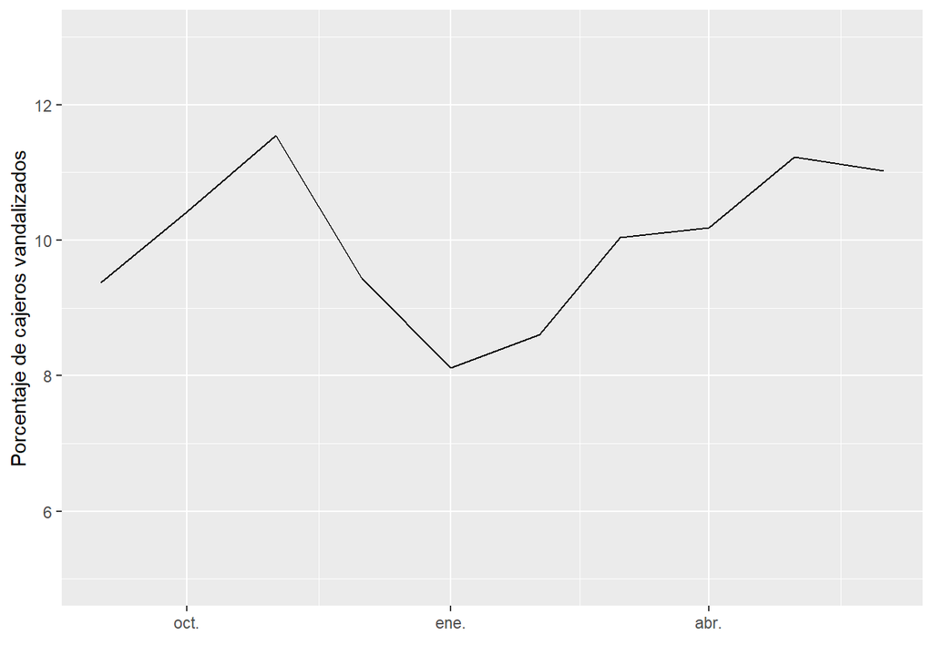

```r
fechas <- unique(info[["Mes"]])
per <- 0

for (i in 1:length(fechas)){
  query <- subset(info, (`Mes`== fechas[i]))
  per[i] <- (nrow(query)/nrow(info))*100
}

Per_Fecha <- do.call(rbind, Map(data.frame, Mes=fechas, Porcentaje=per))
Per_Fecha <- Per_Fecha[order(Per_Fecha$Mes),]

Per_Fecha$Mes <- as.Date(Per_Fecha$Mes)

ggplot(Per_Fecha, aes(Mes, Porcentaje)) + geom_line() +  scale_x_date() + xlab("") + ylab("Porcentaje de cajeros vandalizados") + ylim(5,13)
```

### ENTIDADES CON CAJEROS CERCANOS

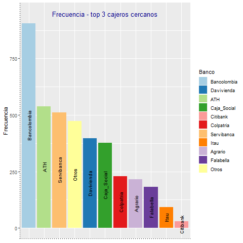

# Exploración de datos

**EXPLORACIÓN DE DATOS**

Copyright © All rights reserved.